# Thomas O'Sullivan

## Part 1: Interpolation

Since we are going to be warping images, we need to make sure we have a good interpolation function to deal with inexact pixel locations.

In the cell below, we want to scale an image by a factor of 2.30 in both x and y. **Write a function called "interpolate" that performs bilinear interpolation.** This function should take in the image and a location (x,y) of interest. It then uses the nearby pixels to interpolate and return an RGB value.

**Note:** For this lab, we will keep images as floats to simplify the interpolation. Thus, output your images as values between 0-1, not 0-255.

```
0.99215686
```

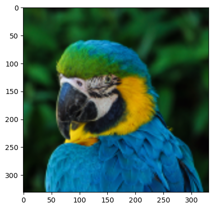

```python
import matplotlib.pyplot as plt
import numpy as np

#Your bilinear interpolation function
def interpolate(image, x, y):

    height, width, length = image.shape

    x0 = int(np.floor(x))
    x1 = min(x0 + 1, width - 1)
    y0 = int(np.floor(y))
    y1 = min(y0 + 1, height - 1)

    dis_x = x - x0
    dis_y = y - y0

    ZeroZero = image[y0, x0]
    OneZero = image[y0, x1]
    ZeroOne = image[y1, x0]
    OneOne = image[y1, x1]

    IV = (1 - dis_x) * (1 - dis_y) * ZeroZero + dis_x * (1 - dis_y) * OneZero + (1 - dis_x) * dis_y * ZeroOne + dis_x * dis_y * OneOne


    return IV



filename = "/Users/sully/Desktop/Lab 4 Data/test.png"
im = plt.imread(filename)

print(np.amax(im))

h,w,_ = im.shape

result = np.zeros((int(2.3*h),(int(2.3*w)),3), dtype="float32")

rows, cols, _ = result.shape

for i in range(rows):
    for j in range(cols):
        result[i,j] = interpolate(im, j/2.3, i/2.3)


plt.imshow(result,vmin=0)
plt.show()
```

## Part 2: Compose (i.e. Backwards Mapping)

Now that we have a interpolation function, we need a function that can compose a source image onto a target image given a transform. In Lab 3, we used Pillow's built-in compose function. You will now implement this yourself using backwards mapping. **This function should also call your interpolate function.**

To implement this function,

- Invert the given transformation. (This is really easy using the NumPy *linalg* library)
- For each pixel in the target image
  - Determine the x and y coordinates of the pixel
  - Homogenize the coordinate
  - Multiply it by the inverse transform
  - Perform the homogenous divide on the new point
  - If the x,y coordinate is within the boundaries of the source image, grab the interpolated value from source image. Otherwise, keep the original pixel in the target image.

For this example, a simple rotation transformation will be given. The source and target image will be the same size, which means part of your rotated image will be cut off on the corners. If done correctly, you should see the parrot rotated onto a purple background. You can assume that all pixels need to be backward mapped. Any pixel/point that maps to a point outside the image boundaries should be skipped. **Don't forget the homogenous divide.**

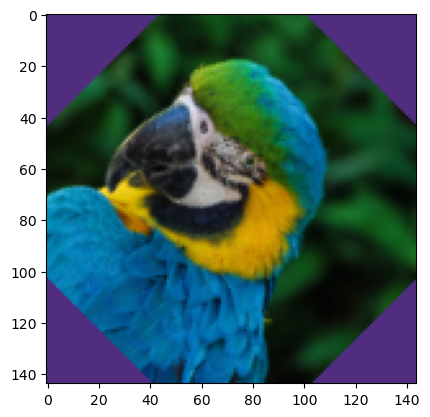

```python
import numpy as np

def compose(source_im, target_im, transform):
    source_im = source_im.astype(np.float32)
    target_im = target_im.astype(np.float32)

    if len(source_im.shape) == 3:
        hs, ws, cs = source_im.shape
    else:
        hs, ws = source_im.shape
        cs = 1

    if len(target_im.shape) == 3:
        ht, wt, _ = target_im.shape
    else:
        ht, wt = target_im.shape

    result = np.copy(target_im)
    inv_transform = np.linalg.inv(transform)

    for y in range(ht):
        for x in range(wt):
            target_coord = np.array([x, y, 1])

            source_coord = np.dot(inv_transform, target_coord).A1

            if source_coord[2] != 0:
                source_x, source_y = source_coord[0] / source_coord[2], source_coord[1] / source_coord[2]
            else:
                continue


            if 0 <= source_x < ws and 0 <= source_y < hs:
                interpolated_value = interpolate(source_im, source_x, source_y)

                if cs > 1:
                    result[y, x, :] = interpolated_value
                else:
                    result[y, x] = interpolated_value
    return result




from math import sin,cos,pi

filename = "/Users/sully/Desktop/Lab 4 Data/test.png"
im = plt.imread(filename)
canvas = np.zeros_like(im) + np.array([[[80/255,45/255,127/255]]]) #ECU Purple

transform = np.matrix([[cos(45 * pi/180), -sin(45 * pi/180), w/2],[sin(45 * pi/180),cos(45 * pi/180),-h/5],[0,0,1]])

result = compose(im,canvas,transform)

plt.imshow(result,vmin=0)
plt.show()
```

## Part 3: Perspective Warp

Now that we have the two specific functions that we need, let's start looking at some more interesting image warping. In class, we discussed how we can use homographies to perform perspective warps. In this lab, we have provided the homography generating code for you.

```python
class Point():
    def __init__(self,x,y):
        self.x = x
        self.y = y

    def __str__(self):
        return "({},{})".format(self.x,self.y)

    def __repr__(self):
        return self.__str__()


def getHomography(s0,s1,s2,s3,t0,t1,t2,t3):

    x0s = s0.x
    y0s = s0.y
    x0t = t0.x
    y0t = t0.y

    x1s = s1.x
    y1s = s1.y
    x1t = t1.x
    y1t = t1.y

    x2s = s2.x
    y2s = s2.y
    x2t = t2.x
    y2t = t2.y

    x3s = s3.x
    y3s = s3.y
    x3t = t3.x
    y3t = t3.y

    #Solve for the homography matrix
    A = np.matrix([
            [x0s, y0s, 1, 0, 0, 0, -x0t*x0s, -x0t*y0s],
            [0, 0, 0, x0s, y0s, 1, -y0t*x0s, -y0t*y0s],
            [x1s, y1s, 1, 0, 0, 0, -x1t*x1s, -x1t*y1s],
            [0, 0, 0, x1s, y1s, 1, -y1t*x1s, -y1t*y1s],
            [x2s, y2s, 1, 0, 0, 0, -x2t*x2s, -x2t*y2s],
            [0, 0, 0, x2s, y2s, 1, -y2t*x2s, -y2t*y2s],
            [x3s, y3s, 1, 0, 0, 0, -x3t*x3s, -x3t*y3s],
            [0, 0, 0, x3s, y3s, 1, -y3t*x3s, -y3t*y3s]
        ])

    b = np.matrix([
            [x0t],
            [y0t],
            [x1t],
            [y1t],
            [x2t],
            [y2t],
            [x3t],
            [y3t]
        ])

    #The homorgraphy solutions a-h
    solutions = np.linalg.solve(A,b)

    solutions = np.append(solutions,[[1.0]], axis=0)

    #Reshape the homography into the appropriate 3x3 matrix
    homography = np.reshape(solutions, (3,3))

    return homography
```

We want to be able to get a new image into the TV set in the image shown below.

To place the bird correctly inside the TV, do the following:

- Determine the homography that maps from the bird image to the TV. Use the `getHomography` function and the provided points.
- For each pixel/point within the target image, backmap those points onto the bird image. Use your `compose` function and make sure it correctly rejects points that do not land within the image boundary

Write a general perspective warp function that completes these steps. **Hint: If your compose/backmap function is written correctly, this should only be 2-3 lines of code.**

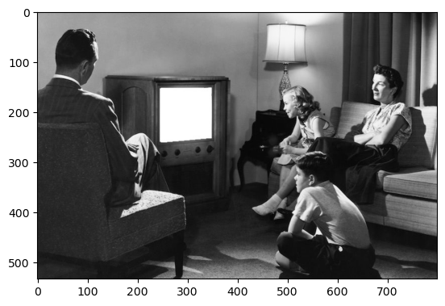

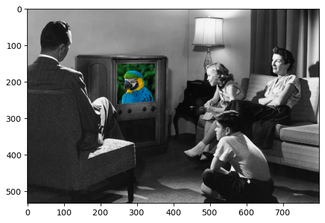

```python
def perspectiveWarp(source_im, target_im, s0, s1, s2, s3, t0, t1, t2, t3):
    homography = getHomography(s0, s1, s2, s3, t0, t1, t2, t3)
    result = compose(source_im, target_im, homography)
    return result


filename = "/Users/sully/Desktop/Lab 4 Data/test.png"
im = plt.imread(filename)

h,w,_ = im.shape

s0 = Point(0,0)
s1 = Point(w-1,0)
s2 = Point(w-1,h-1)
s3 = Point(0,h-1)

t0 = Point(245,152)
t1 = Point(349,150)
t2 = Point(349,253)
t3 = Point(246,261)

tv = plt.imread('/Users/sully/Desktop/Lab 4 Data/tv.png')
plt.imshow(tv,vmin=0)
plt.show()

result = perspectiveWarp(im,tv,s0,s1,s2,s3,t0,t1,t2,t3)

plt.imshow(result,vmin=0)
plt.show()
```

# Part 4: Speed Up

We have a complete perspective warping algorithm now, but you may have noticed that it runs a little slowly. This is because it checks every pixel in the target image to see if it needs to be backmapped. A much faster solution is create a min-max bounding box around the warping points and only checking pixels within that bounding box. **See the bounding box example image provided with the lab.** You may find `np.amax()` and `np.amin()` to be helpful.

For this last part of the lab, rewrite your perspective warp and compose functions as needed so that they only check pixels in the relevant bounding box in the image. Compare the run times between the previous approach and your new method.

[figure not shown]

```
Slow Method: 1.1033051013946533
```

[figure not shown]

```
Fast Method: 0.07360172271728516
```

[figure not shown]

```python
def composeFast(source_image, target_image, homography, bbox_min_x, bbox_min_y, bbox_max_x, bbox_max_y):
    target_h, target_w, _ = target_image.shape
    source_h, source_w, _ = source_image.shape

    inv_transform = np.linalg.inv(homography)

    for y in range(bbox_min_y, bbox_max_y + 1):
        for x in range(bbox_min_x, bbox_max_x + 1):
            target_coord = np.array([x, y, 1])
            source_coord = np.dot(inv_transform, target_coord).A1

            if source_coord[2] != 0:
                source_x, source_y = source_coord[0] / source_coord[2], source_coord[1] / source_coord[2]
            else:
                continue

            if 0 <= source_x < source_w and 0 <= source_y < source_h:
                interpolated_value = interpolate(source_image, source_x, source_y)
                target_image[y, x] = interpolated_value

    return target_image

def perspectiveWarpFast(source_im, target_im, s0, s1, s2, s3, t0, t1, t2, t3):
    result = np.copy(target_im)

    homography = getHomography(s0, s1, s2, s3, t0, t1, t2, t3)

    bbox_min_x = int(np.amin([t0.x, t1.x, t2.x, t3.x]))
    bbox_max_x = int(np.amax([t0.x, t1.x, t2.x, t3.x]))
    bbox_min_y = int(np.amin([t0.y, t1.y, t2.y, t3.y]))
    bbox_max_y = int(np.amax([t0.y, t1.y, t2.y, t3.y]))

    result = composeFast(source_im, result, homography, bbox_min_x, bbox_min_y, bbox_max_x, bbox_max_y)

    return result



from time import time

museum = plt.imread('/Users/sully/Desktop/Lab 4 Data/museum.png')
plt.imshow(museum,vmin=0)
plt.show()

filename = "/Users/sully/Desktop/Lab 4 Data/test.png"
im = plt.imread(filename)

h,w,_ = im.shape

s0 = Point(0,0)
s1 = Point(w-1,0)
s2 = Point(w-1,h-1)
s3 = Point(0,h-1)

t0 = Point(268,230)
t1 = Point(349,249)
t2 = Point(347,361)
t3 = Point(267,363)

start = time()
result1 = perspectiveWarp(im,museum,s0,s1,s2,s3,t0,t1,t2,t3)
print("Slow Method:",time()-start)

plt.imshow(result1,vmin=0)
plt.show()

start = time()
result2 = perspectiveWarpFast(im,museum,s0,s1,s2,s3,t0,t1,t2,t3)
print("Fast Method:",time()-start)

#plt.imsave("Output.png",result2)
plt.imshow(result2,vmin=0)
plt.show()
```

```python
from nbconvert import HTMLExporter
import nbformat

notebook_filename = "/Users/sully/Desktop/Fall_2024/Computer_vis/Lab_4/Lab4-ImageWarping.ipynb"
with open(notebook_filename, 'r', encoding='utf-8') as f:
    notebook_content = nbformat.read(f, as_version=4)

html_exporter = HTMLExporter()
(body, resources) = html_exporter.from_notebook_node(notebook_content)

output_filename = "Image_Warping.html"
with open(output_filename, 'w', encoding='utf-8') as f:
    f.write(body)
```